# Contaminación en el aire en la ciudad de Madrid

## 1.2 Análisis exploratorio de la renta municipal en España

**Exercise 2** ¿Cuál es la renta per cápita media de los municipios españoles en 2019?

```r
summary(renta$`2019`)
```

```
   Min. 1st Qu.  Median    Mean 3rd Qu.    Max.
   5898    9995   11428   11611   12930   26367
```

**Exercise 3** ¿Es la renta media la misma en todos los municipios?

```r
library("summarytools")
renta |>
  select(`2019`) |>
  descr()
```

```
Descriptive Statistics
2019
N: 6424

                        2019
----------------- ----------
             Mean   11611.25
          Std.Dev    2211.72
              Min    5898.00
               Q1    9994.50
           Median   11427.50
               Q3   12930.00
              Max   26367.00
              MAD    2173.49
              IQR    2934.75
               CV       0.19
         Skewness       0.77
      SE.Skewness       0.03
         Kurtosis       1.33
          N.Valid    6424.00
        Pct.Valid     100.00
```

¡Qué lio! Mejor un gráfico que una tabla (J. Tukey)

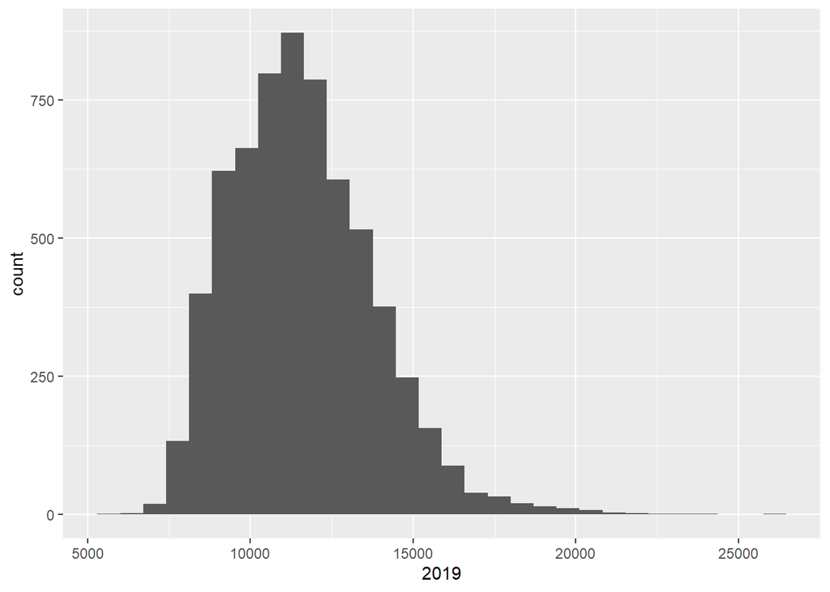

```r
ggplot(data = renta, aes(x=`2019`)) +
  geom_histogram() #30 bins por defecto
```

¡Qué histograma más feo! Vamos a mejorarlo

**Tu turno**

Completa las partes del código señaladas por `______` o `xxx` para obtener el resultado propuesto.

```r
p_renta_2019 <- ggplot(renta, aes(`2019`)) +
  geom_xxxxxx(col = "darkred",
                 fill = "bisque",
                 bins = nclass.Sturges(renta_municipio_data$`2019`)) +
  geom_xxxxxx(aes(xintercept = mean(`2019`)),
             color = "red",
             linetype = "dashed",
             linewidth = 1) +
  geom_xxxxxx(aes(x = mean(`2019`),
                y = 100,
                label = round(mean(`2019`), 2)),
            color = "darkred") +
  labs(title = "Distribución de la renta por municipios",
       x = "Renta per cápita",
       y = "Frecuencia") +
  theme_xxxxxx()

p_renta_2019
```

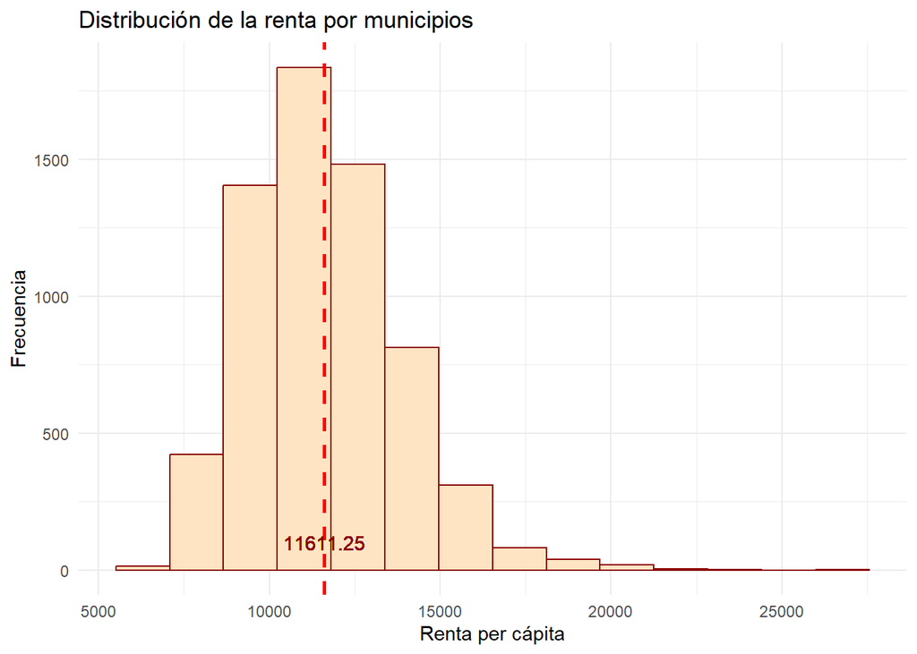

**Exercise 4** ¿Sería mejor tener un gráfico de densidad? ¿Cómo se interpretaría? ¿Qué diferencias hay respecto al histograma?

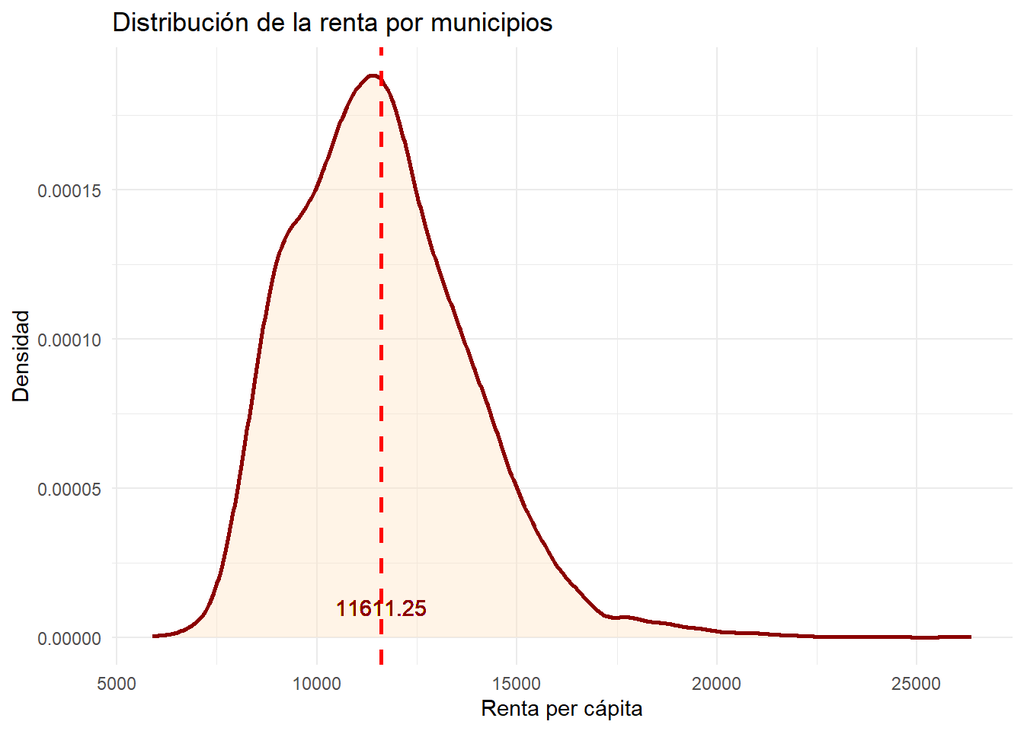

```r
p_renta_2019_density <- ggplot(renta, aes(`2019`)) +
  geom_density(fill = "bisque",
               alpha= 0.4,
               color="darkred",
               lwd = 1) +
  geom_vline(aes(xintercept = mean(`2019`)),
             color = "red",
             lwd = 1,
             linetype = "dashed") +
  geom_text(aes(x = mean(`2019`),
                y = 0.00001,
                label = round(mean(`2019`), 2)),
            color = "darkred") +
  labs(title = "Distribución de la renta por municipios",
       x = "Renta per cápita",
       y = "Densidad") +
  theme_minimal()

p_renta_2019_density
```

**Exercise 5** ¿Cuál me gusta más? ¿Histograma o densidad? ¿Juntos?

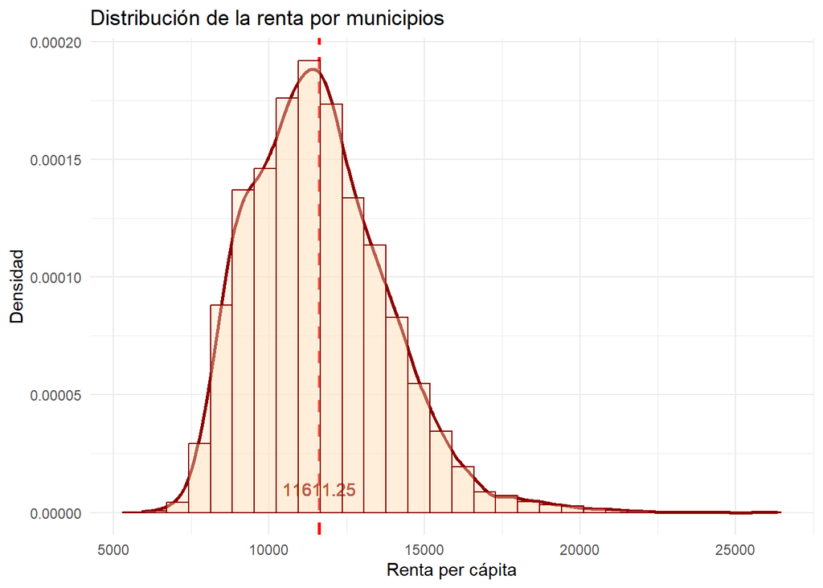

```r
p_renta_2019_density +
  geom_histogram(aes(y=..density..),
                 fill = "bisque",
                 color="darkred",
                 alpha = 0.4)
```

**Exercise 6** ¿Por qué no tener un 5-summary plot? ¿Qué nos dice?

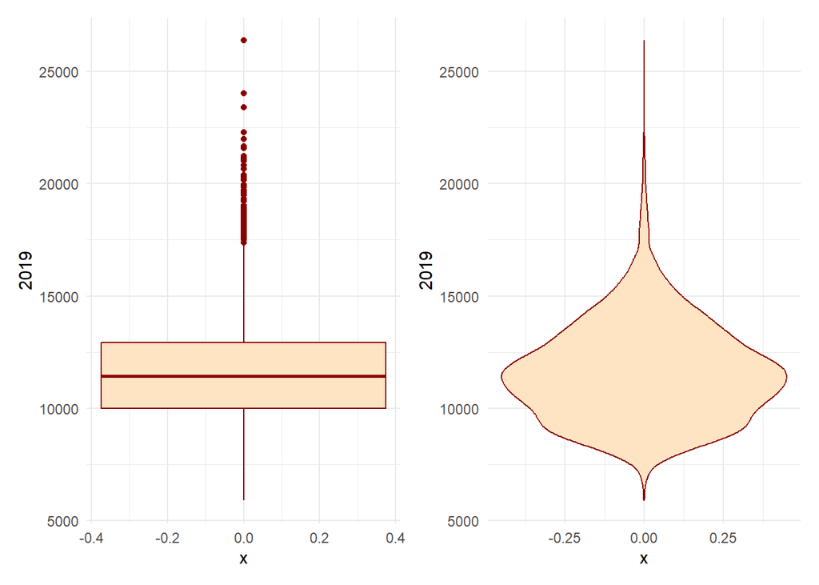

```r
p <- renta |>
  ggplot(aes(x=0, y= `2019`))

boxplot <- p +
  geom_boxplot(color = "darkred", fill = "bisque") +
  theme_minimal()

violin <- p + geom_violin(color = "darkred", fill = "bisque") +
  theme_minimal()

library(patchwork)
boxplot + violin
```

**Exercise 7** ¿En los años anteriores la renta ha sido similar?

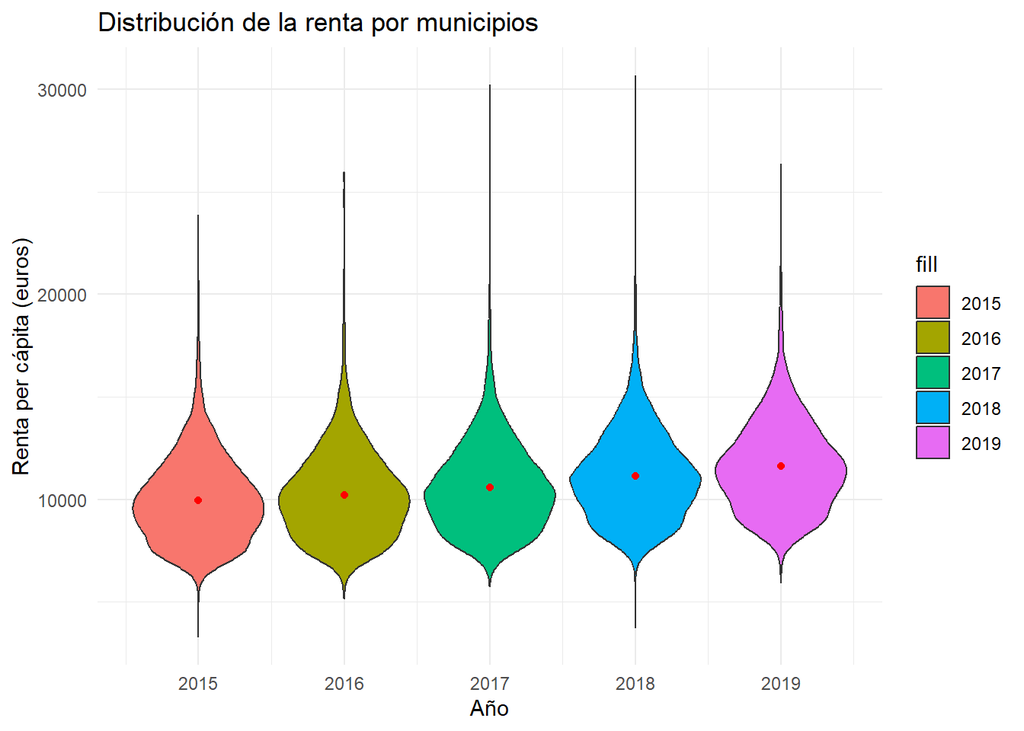

```r
p <- renta |>
  ggplot(aes(x=0, y= `2015`))

p + geom_violin( ) +
     geom_violin(aes(fill = "2015")) +
     geom_violin(aes(x=1, y= `2016`, fill = "2016")) +
     geom_violin(aes(x=2, y= `2017`, fill = "2017")) +
     geom_violin(aes(x=3, y= `2018`, fill = "2018")) +
     geom_violin(aes(x=4, y= `2019`, fill = "2019")) +
  # añade la media de cada año al violín
  geom_point(aes(x=0, y=mean(`2015`)), color = "red") +
  geom_point(aes(x=1, y=mean(`2016`)), color = "red") +
  geom_point(aes(x=2, y=mean(`2017`)), color = "red") +
  geom_point(aes(x=3, y=mean(`2018`)), color = "red") +
  geom_point(aes(x=4, y=mean(`2019`)), color = "red") +
  theme_minimal() +
    scale_x_continuous(breaks = c(0, 1, 2, 3, 4),
                       labels = c("2015", "2016", "2017", "2018", "2019")) +
     labs(title = "Distribución de la renta por municipios",
          x = "Año",
          y = "Renta per cápita (euros)")
```

**Exercise 8** ¿Es necesario el color? ¿Queremos ver también la evolución a lo largo del tiempo? Pues quizá podemos matar dos pájaros de un tiro… veamos…

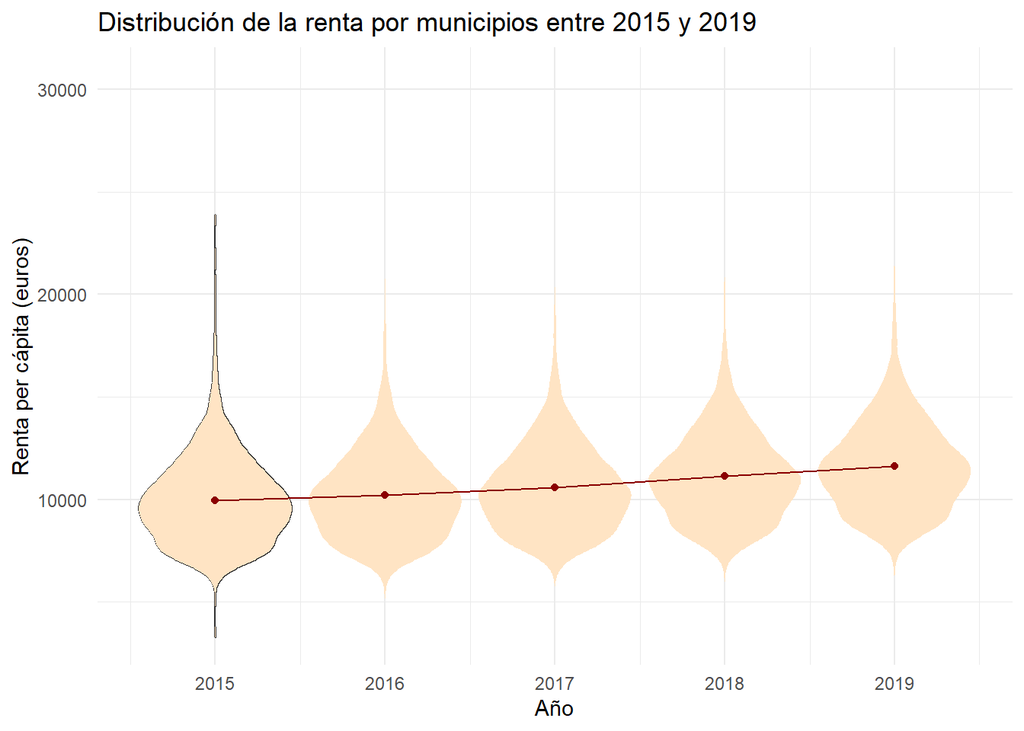

```r
medias <- renta |>
  summarise(across(`2015`:`2019`, mean, na.rm = TRUE)) |>
  pivot_longer(cols = `2015`:`2019`,
               names_to = "pos",
               values_to = "renta") |>
  mutate(pos = as.numeric(pos) - 2015)
p <- renta |>
  ggplot(aes(x=0, y= `2015`))

p + geom_violin( ) +
  geom_violin(aes(x=0, y= `2015`), fill = "bisque", col = "transparent") +
  geom_violin(aes(x=1, y= `2016`), fill = "bisque", col = "transparent") +
  geom_violin(aes(x=2, y= `2017`), fill = "bisque", col = "transparent") +
  geom_violin(aes(x=3, y= `2018`), fill = "bisque", col = "transparent") +
  geom_violin(aes(x=4, y= `2019`), fill = "bisque", col = "transparent") +
  # añade la media de cada año al violín
  geom_point(aes(x=0, y=mean(`2015`)), color = "darkred") +
  geom_point(aes(x=1, y=mean(`2016`)), color = "darkred") +
  geom_point(aes(x=2, y=mean(`2017`)), color = "darkred") +
  geom_point(aes(x=3, y=mean(`2018`)), color = "darkred") +
  geom_point(aes(x=4, y=mean(`2019`)), color = "darkred") +
  # añade la línea de tendencia uniendo las medias
  geom_line(data = medias,
            aes(x = pos,
                y = renta,
                group = 1),
            color = "darkred") +
  theme_minimal() +
  scale_x_continuous(breaks = c(0, 1, 2, 3, 4),
                     labels = c("2015", "2016", "2017", "2018", "2019")) +
  labs(title = "Distribución de la renta por municipios entre 2015 y 2019",
       x = "Año",
       y = "Renta per cápita (euros)")
```

**Exercise 9** ¿Son los municipios de norte más ricos que los del sur de España en 2019?

```r
library("sf")
help(municipios)

munis_renta <- municipios |>
  left_join(renta) |>   # une datasets
  select(name, cpro, ine.prov.name, cmun,
       `2015`,`2016`,`2017`,`2018`,`2019`) # selecciona variables
```

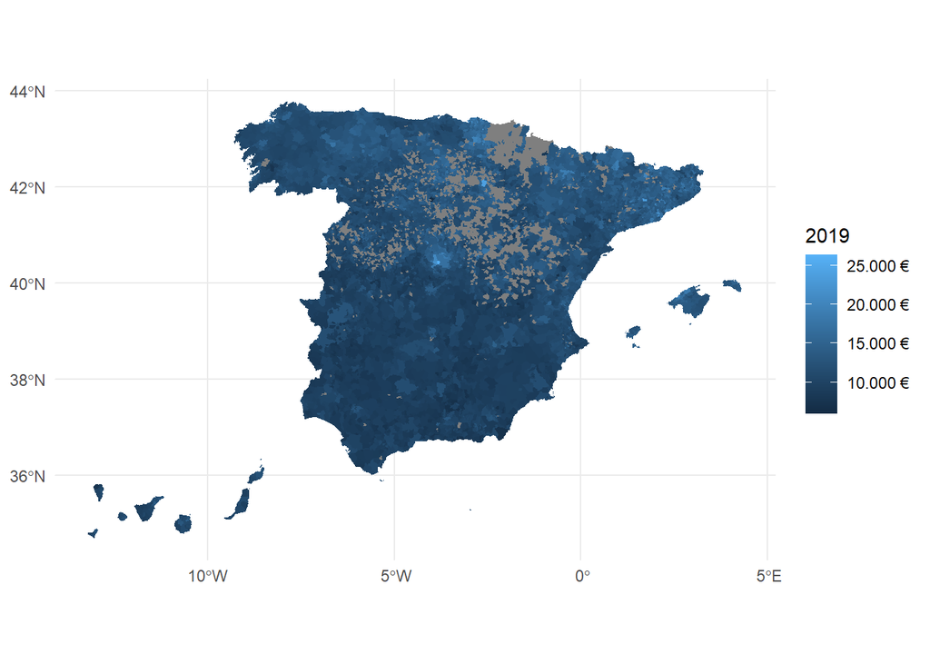

```r
ggplot(munis_renta) +
  geom_sf(aes(fill = `2019`), color = NA) +
  scale_fill_continuous(labels = scales::label_number(big.mark = ".",
                                                      decimal.mark = ",",
                                                      suffix = " €" )) +
  theme_minimal()
```

## 1.3 Que no nos mientan con la estadística (ni con la visualización)

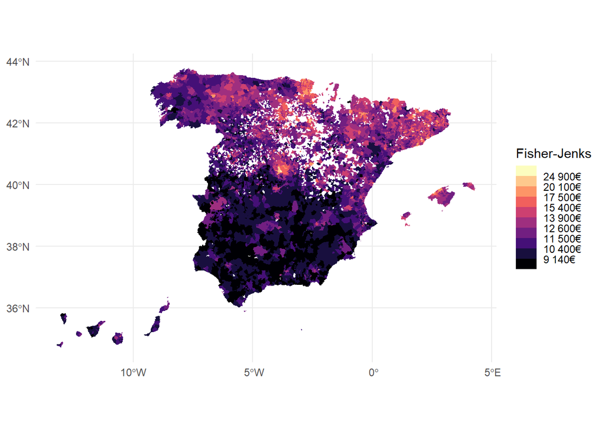

```r
munis_renta_clean <- munis_renta |>
  filter(!is.na(`2019`))

# crea Fisher-Jenks clases
library(classInt)
fisher <- classIntervals(munis_renta_clean$`2019`,
                         style = "fisher",
                         n = 10)
ggplot(munis_renta_clean) +
  geom_sf(aes(fill = cut(`2019`, fisher$brks)), color = NA) +
  scale_fill_viridis_d(option= "A",
                       labels= scales::label_number(suffix= "€")) +
  guides(fill = guide_colorsteps()) +
  labs(fill= "Fisher-Jenks") +
  theme_minimal()
```

**Exercise 10** ¿Cuál es la provincia con mayor renta media municiapal en 2019? ¿Y la que menos renta media tiene?

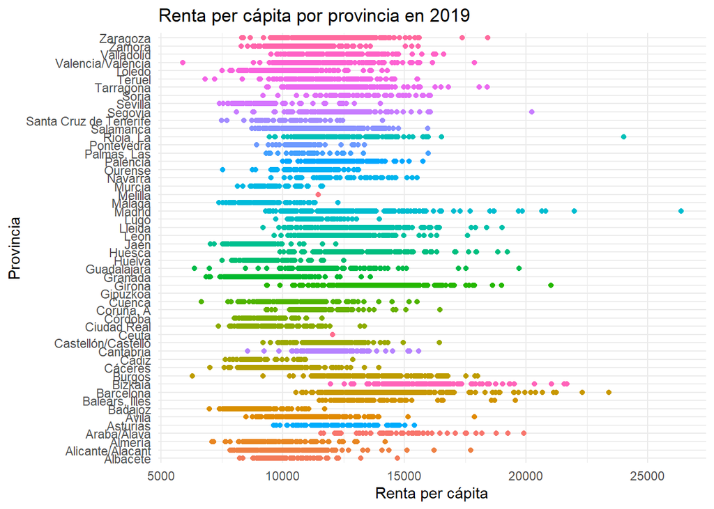

```r
munis_renta |>
  ggplot(aes(x = `2019`, y = ine.prov.name, color = cpro)) +
  geom_point() +
  labs(title = "Renta per cápita por provincia en 2019",
       x = "Renta per cápita",
       y = "Provincia") +
  theme_minimal() +
  theme(legend.position = "none")
```

Mejor los ordenamos las provincias. Y de nuevo, ¿nos aporta el color?

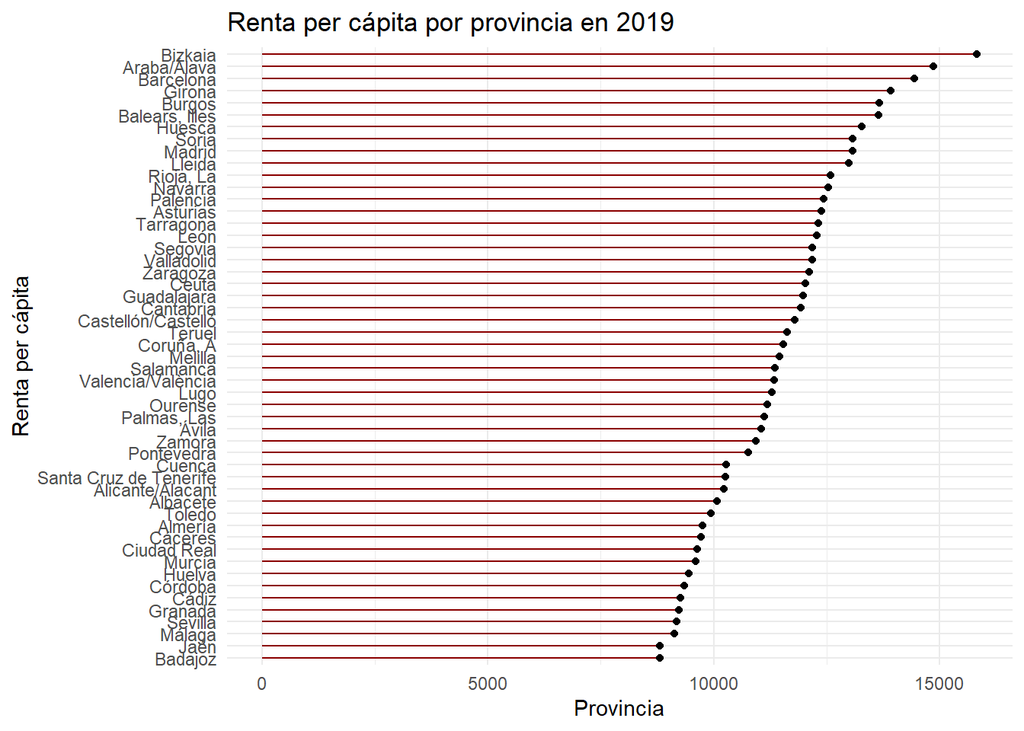

```r
munis_renta2 <- munis_renta |>
  group_by(ine.prov.name) |>
  summarise(pro2019 = mean(`2019`, na.rm = TRUE)) |>
  arrange(desc(pro2019)) |>
  st_drop_geometry() |>
  filter(!is.na(pro2019))
munis_renta2_plot <- ggplot(munis_renta2, aes(y = pro2019,
                         x = reorder(ine.prov.name, pro2019)),
                         color = "darkred") +
  geom_segment(aes(x= reorder(ine.prov.name, pro2019),
                   xend = reorder(ine.prov.name, pro2019),
                   y = 0,
                   yend = pro2019),
               color ="darkred") +
  geom_point() +
  coord_flip() +
  labs(title = "Renta per cápita por provincia en 2019",
       x = "Renta per cápita",
       y = "Provincia") +
  theme_minimal()
munis_renta2_plot
```